# FordGoBike 2017

## Preliminary Wrangling

> bicycle-sharing systems is been growing in number and popularity in cities across the world. bicycle-sharing systems allow users to rent the bicycles as long as the users needs it.Bicycle-sharing systems have deployes new technologies like gps to track the distance,time etc.It is easy for a user to access a lock within the system to unlock or return bicycles. In this project, I will perform an exploratory analysis on FordGoBike 2017 data.

## **Univariate plotting:**

## **How many bike rides are done per month?**

**To find this result we are going to use the countplot/barplot for visualization:**

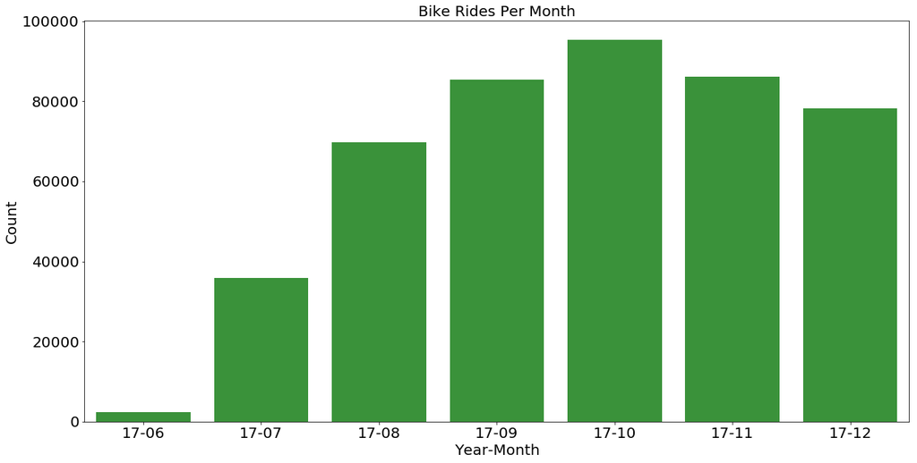

```python
#plotting the start_year_month from the data to find the number of bike rides in every month
plt.figure(figsize=(20,10));
base_color=sb.color_palette()[2]
sb.countplot(data=df_clean.sort_values(by='start_year_month'),x='start_year_month',color=base_color);
plt.xlabel('Year-Month',fontsize=20);
plt.ylabel('Count',fontsize=20)
plt.xticks(fontsize=20);
plt.yticks(fontsize=20);
plt.title('Bike Rides Per Month',fontsize=20);
```

## **Bivariate Plotting:**

## **Age Count for the Genders.**

**To find this result we are going to use the Violinplot for visualization:**

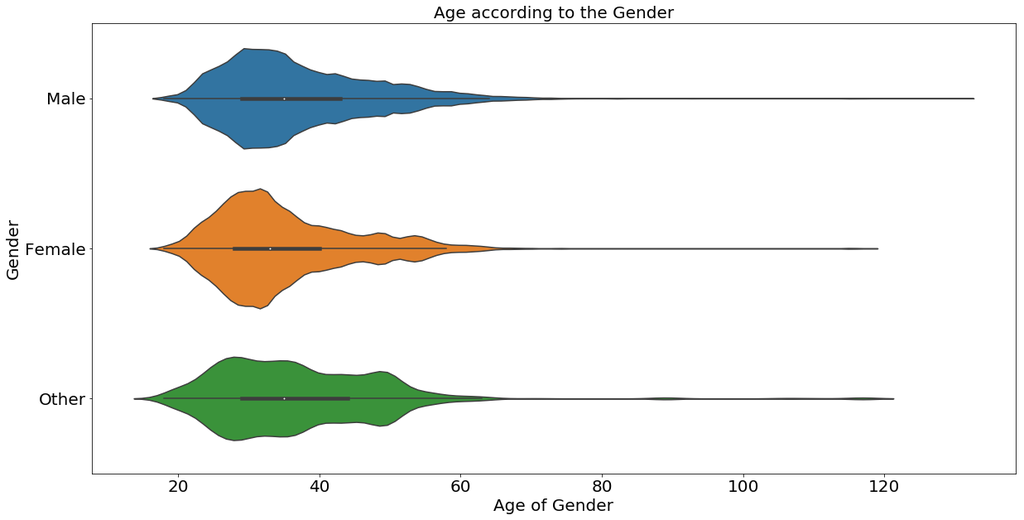

```python
#plotting the member_gender and member_age columns from the data to find which gender are more according to the age groups
plt.figure(figsize=(20,10));
sb.violinplot(data=df_clean,y='member_gender',x='member_age');
plt.xticks(fontsize=20);
plt.yticks(fontsize=20);
plt.xlabel('Age of Gender',fontsize=20);
plt.ylabel('Gender',fontsize=20);
plt.title('Age according to the Gender',fontsize=20);
```

## **Result:**

Upon visualisation the FordGoBike the genders are unique at the age 30,Female customers are more between the age 30-40,Male customers are mre between the age 30-45 and other are between 30-50.

## **Age Count for the User Types.**

**To find this result we are going to use the Boxplot for visualization:**

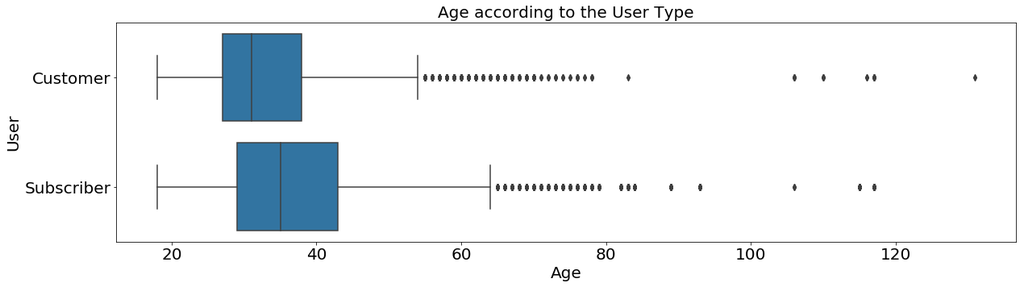

```python
#plotting the user_type and member_age columns from the data to find which users are more according to the age groups
base_color = sb.color_palette()[0]
plt.figure(figsize=(20,5));
sb.boxplot(data = df_clean, x = 'member_age', y = 'user_type', color = base_color);
plt.title('Age according to the User Type',fontsize=20);
plt.xticks(fontsize=20);
plt.yticks(fontsize=20);
plt.xlabel('Age',fontsize=20);
plt.ylabel('User',fontsize=20);
```

## **Month wise usage from the User Type.**

**To find this result we are going to use the clustered barplot for visualization:**

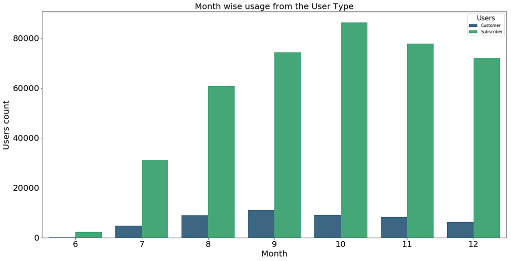

```python
#plotting the user_type and start_month columns from the data to find which users have more usage in every month
plt.figure(figsize=(20,10));
ax=sb.countplot(data = df_clean, x = 'start_month',hue='user_type', palette = "viridis");
plt.title('Month wise usage from the User Type',fontsize=20);
plt.xticks(fontsize=20);
plt.yticks(fontsize=20);
plt.xlabel('Month',fontsize=20);
plt.ylabel('Users count',fontsize=20);
leg = ax.legend()
leg.set_title('Users',prop={'size':16})
ax = plt.gca()
```

## **Result:**

Upon visualisation the FordGoBike the subscriber in the month 10 are more usage of bikes and customers in the month 9 are more usage of bikes.

## **Weekly Usage of FordGoBikes from the Users**

**To find this result we are going to use the clustered barplot for visualization:**

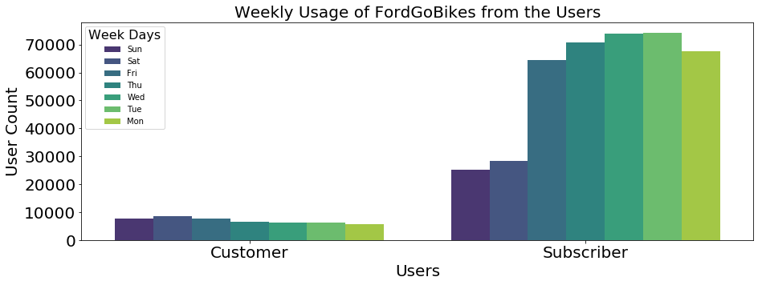

```python
#plotting the user_type and start_weekday columns from the data to find which users have more usage in a week
plt.figure(figsize=(15,5));
ax=sb.countplot( data = df_clean,x = "user_type", palette = "viridis", hue = "start_weekday");
plt.title('Weekly Usage of FordGoBikes from the Users',fontsize=20);
plt.xticks(fontsize=20);
plt.yticks(fontsize=20);
plt.xlabel('Users',fontsize=20);
plt.ylabel('User Count',fontsize=20);
leg = ax.legend()
leg.set_title('Week Days',prop={'size':16})
ax = plt.gca()
```

## **PerDay Usage of Bikes according to the genders in 2017**

**To find this result we are going to use the Boxplot for visualization:**

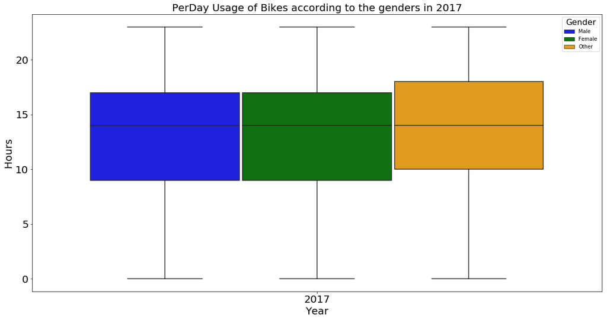

```python
#plotting start_year and start_hour columns with member_gender column which gender has used the ride at what time period
#the rides of the whole year.
plt.figure(figsize=(20,10))
ax=sb.boxplot(x='start_year', y='start_hour',hue='member_gender', palette=['blue', 'green','orange'],data=df_clean);
plt.title('PerDay Usage of Bikes according to the genders in 2017',fontsize=20);
plt.xticks(fontsize=20);
plt.yticks(fontsize=20);
plt.xlabel('Year',fontsize=20);
plt.ylabel('Hours',fontsize=20);
leg = ax.legend()
leg.set_title('Gender',prop={'size':16})
ax = plt.gca()
```

## **WeekDays Usage of Bikes according to the genders**

**To find this result we are going to use the Boxplot for visualization:**

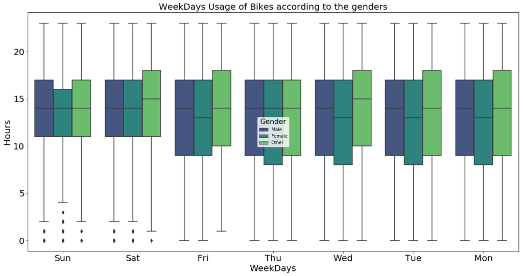

```python
#plotting start_weekday and start_hour columns with member_gender column which gender has used the ride at what time period
#the rides are taken in a week.
plt.figure(figsize=(20,10))
ax=sb.boxplot(x="start_weekday", y="start_hour",hue="member_gender", palette="viridis",data=df_clean);
plt.title('WeekDays Usage of Bikes according to the genders',fontsize=20);
plt.xticks(fontsize=20);
plt.yticks(fontsize=20);
plt.xlabel('WeekDays',fontsize=20);
plt.ylabel('Hours',fontsize=20);
leg = ax.legend()
leg.set_title('Gender',prop={'size':16})
ax = plt.gca()
```

## **Result:**

Upon visualisation the FordGoBike the genders are unique in wednesday and friday.but the business of FordGoBike is less in the weekends.

## **weekDay Usage of Bikes**

**To find this result we are going to use the Boxplot for visualization:**

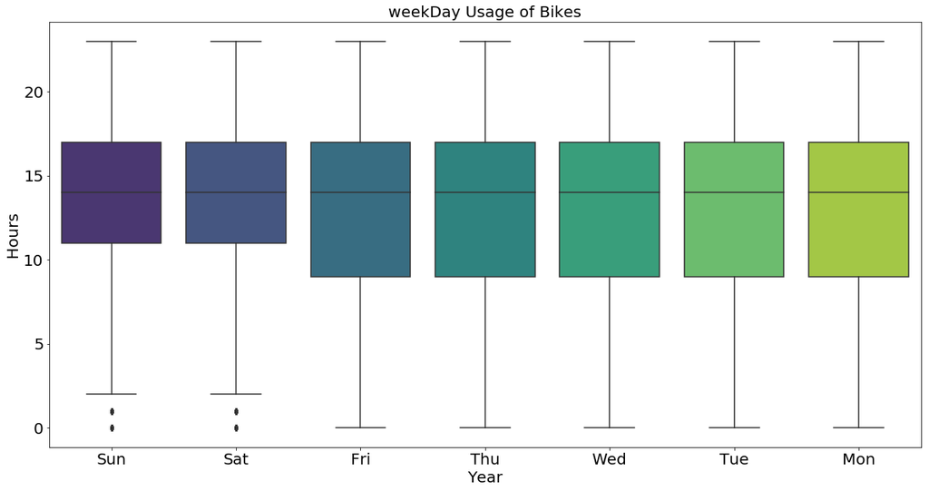

```python
#plotting start_weekday and start_hour columns in order to find which weekday has used the ride
#and at what time period the rides are taken in a week.
plt.figure(figsize=(20,10))
sb.boxplot(x="start_weekday", y="start_hour",palette="viridis",data=df_clean);
plt.title('weekDay Usage of Bikes',fontsize=20);
plt.xticks(fontsize=20);
plt.yticks(fontsize=20);
plt.xlabel('Year',fontsize=20);
plt.ylabel('Hours',fontsize=20);
```

## **Result:**

Upon visualisation the FordGoBike,in week days the usage of bikes are between 9 Am to 5 Pm and in weekends the usage of bike are between 11 Am to 5 Pm

## **Distance travelled by the genders at a particular Hour**

**To find this result we are going to use the Boxplot for visualization:**

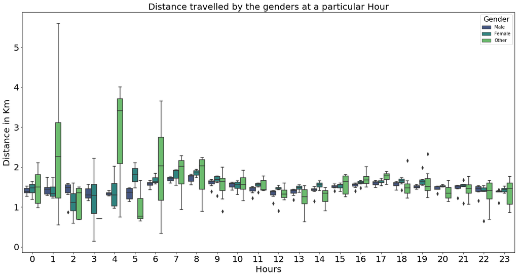

```python
#grouping start_year_month,member_gender and start_hour columns and plotting the start_hour and distance_km with member_gender
#in order to find which gender has travelled a distance in km
plt.figure(figsize=(20,10))
gg=df_clean.groupby(["start_hour", "start_year_month", "member_gender"], as_index = False).mean()
ax=sb.boxplot(x = "start_hour", y = "distance_km", data =gg , palette = "viridis", hue = "member_gender");
plt.title('Distance travelled by the genders at a particular Hour',fontsize=20);
plt.xticks(fontsize=20);
plt.yticks(fontsize=20);
plt.xlabel('Hours',fontsize=20);
plt.ylabel('Distance in Km',fontsize=20);
leg = ax.legend()
leg.set_title('Gender',prop={'size':16})
ax = plt.gca()
```

## **Result:**

Upon visualisation the FordGoBike,the other genders have ride the maximum distance than male and female genders.

## **Distance travelled by the Users**

**To find this result we are going to use the Boxplot for visualization:**

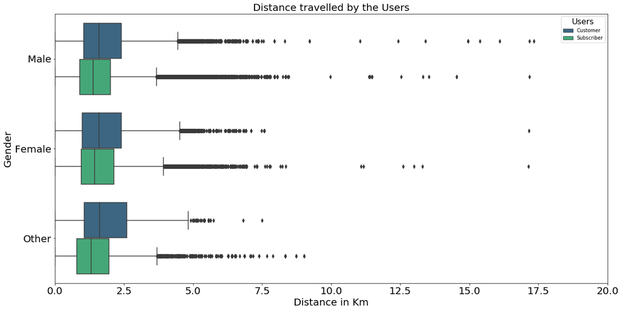

```python
#plotting distance_km and member_gender columns with user_types in order to find which user has travelled a long distance.
plt.figure(figsize=(20,10))
ax=sb.boxplot(data=df_clean,x="distance_km", y="member_gender",hue='user_type',palette="viridis");
plt.title('Distance travelled by the Users',fontsize=20);
plt.xticks(fontsize=20);
plt.yticks(fontsize=20);
plt.xlabel('Distance in Km',fontsize=20);
plt.ylabel('Gender',fontsize=20);
plt.xlim(0,20);
leg = ax.legend()
leg.set_title('Users',prop={'size':16})
ax = plt.gca()
```

## **Result:**

Upon visualisation the FordGoBike,Customers have ride the bike for a maximum distance than Subscribers.

## **Multivariate:**

## **HeatMap of the FordGoBike Data:**

**To find this result we are going to use the seaborns heatmap for visualization:**

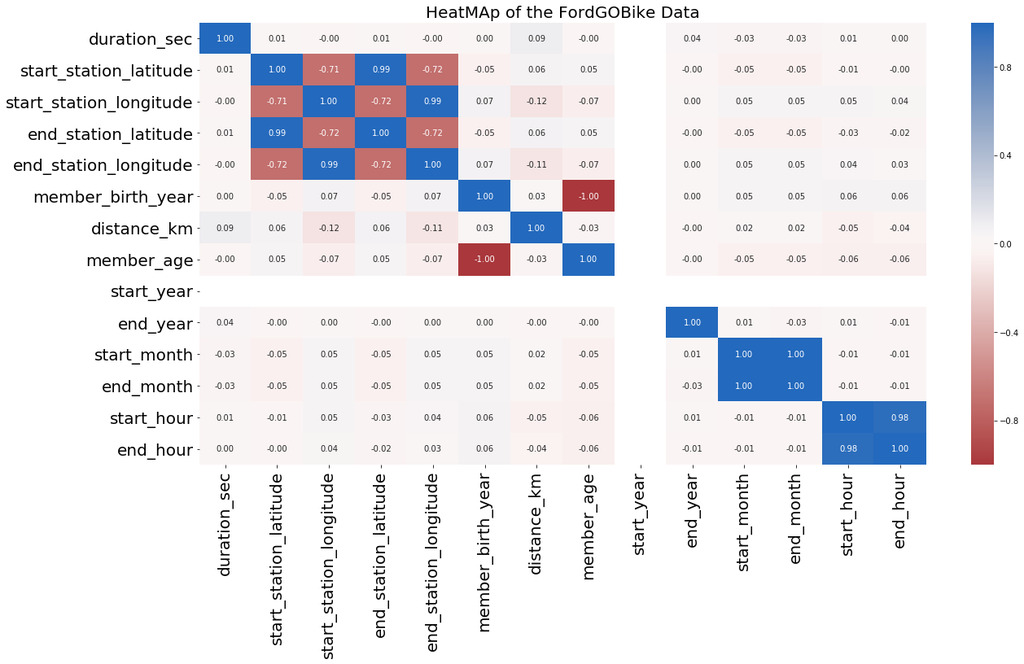

```python
#here we are plotting all the numerical columns from the data and that is called heat map
plt.figure(figsize=(20,10));
sb.heatmap(df_clean.corr(), annot = True, fmt = '.2f', cmap = 'vlag_r', center = 0);
plt.title('HeatMAp of the FordGOBike Data',fontsize=20);
plt.xticks(fontsize=20);
plt.yticks(fontsize=20);
```

## **PairGrid For numerial variables**

**To find this result we are going to use the seaborns pairgrid for visualization:**

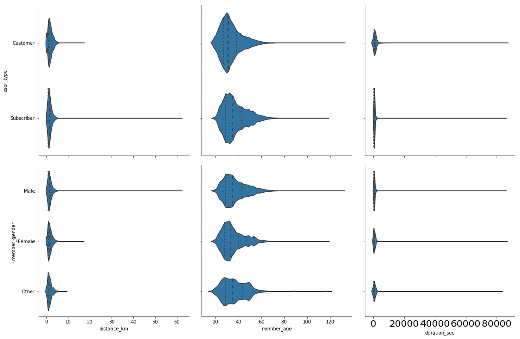

```python
#here we are plotting the pairgrid plot to compare two categorical columns with three quantitative columns
g=sb.PairGrid(data = df_clean, x_vars = ['distance_km', 'member_age', 'duration_sec'],
                y_vars = ['user_type','member_gender'],size=5)
g.map(sb.violinplot, inner = 'quartile')
plt.xticks(fontsize=20);
plt.yticks(fontsize=20);
```

```python
!jupyter nbconvert slide_deck_template.ipynb --to slides --post serve --template output_toggle
```

[output not shown]